# R Workshop 9: Outliers and Psychometrics

Benjamin Manning

07/07/2021

# 1 Before we get started

*Having trouble remembering what exactly an R Markdown is? Want some more resources for learning R?*

- Review what an R Markdown is here.
- Explore further resources for learning R here.

## 1.1 Recap: What we learned in the previous tutorial

In the last two tutorials, we learned about the magic of ggplot:

- the foundations of the grammar of graphics
- most useful univariate and bivariate geoms
- common aesthetics
- coordinate and facet functions
- how to present your graphs: labeling, titles, and themes

## 1.2 Overview: What we’ll learn here

Now that we’ve learned how to load, clean, and visualize our data, we can dive into the first step of analyses. This is technically a psychology course, sooooooo we should probably incorporate some psych ;). What *is* the first step in analysis? We might call them **preliminary analyses** (surprise, surprise), or, specifically what we will be covering here, **outliers and psychometrics**. Other times in other academic disciplines this may be called **Exploratory Data Analysis (EDA)** These analyses deal with the issue of measurement: Do our statistical estimates approximate the data? Are our measures reliable? How many dimensions do our measures have? Are we justified in making composite scores?

Here’s an overview of the topics we’ll explore:

- Outliers
  - Univariate outliers
  - Bivariate outliers
  - Multivariate outliers
- Reliability
  - Cronbach’s Alpha
  - Omega
- Factor analysis
  - Exploratory factor analysis
  - Parallel analysis

# 2 A problem

We have a problem. Our growth mindset intervention seems to have gone terribly wrong.

To see what’s wrong, let’s load in our data (and properly order our group variable):

```r
##reminder: "header = TRUE" tells the function that the top row of our data is, in fact, variable *names* and not actual data; "stringsAsFactors = TRUE" reads in character (aka string) variables (like our group_f variable) as factors rather than characters.
gm <- read.csv("growth mindset study_cleaned3.csv", header = TRUE, stringsAsFactors = TRUE)

gm %<>% mutate(group_f = ordered(group_f, levels = c("Control", "Self-esteem", "Growth Mindset")))
```

Visuals and distributions are always a superb way to start combing through some data! So, let’s take a look. We can see how our intervention fared by creating plots of means across intervention conditions. And, as you may remember, to create those plots, we first need to manipulate our data into like-form: means for each outcome (`gpa` and `grit`) across intervention condition (`group_f`).

```r
gm_means <- gm %>%
              group_by(group_f) %>%
                summarise(gpa_mean = mean(gpa, na.rm = TRUE),
                          gpa_sd = sd(gpa, na.rm = TRUE),
                          grit_mean = mean(grit, na.rm = TRUE),
                          grit_sd = sd(grit, na.rm = TRUE))
```

Now, here’s the problem: when we plot our outcomes by intervention group, it’s not at all like what we expected. Students in the growth mindset condition seem to have gotten higher grades, but they also seem to be *lower* than the control group in grit. The worst possible outcome for an intervention is that we made students *worse* on what we were trying to help. We also expected the growth mindset condition to impact GPA and grit in similar ways, so we’re not sure how to interpret these findings.

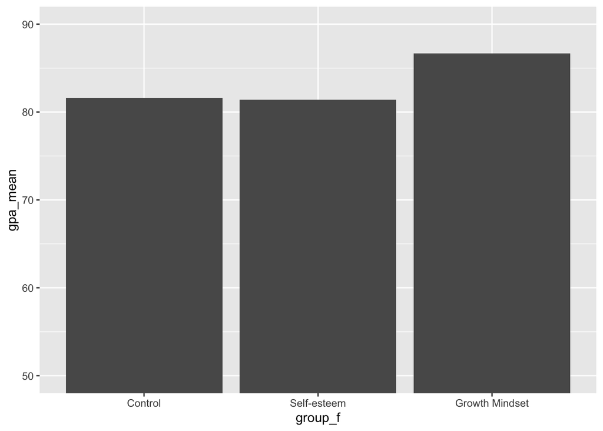

```r
gm_means %>%
  ggplot(aes(x = group_f, y = gpa_mean)) +
  geom_col() +
  coord_cartesian(ylim = c(50, 90))
```

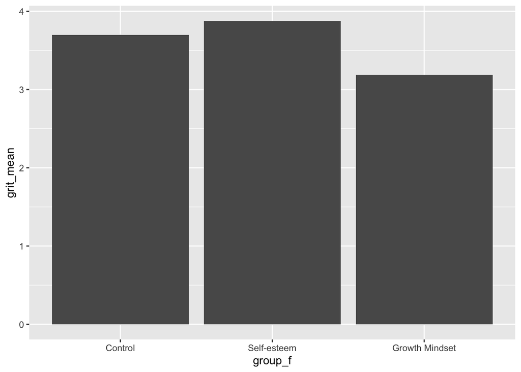

```r
gm_means %>%
  ggplot(aes(x = group_f, y = grit_mean)) +
  geom_col()
```

Our plots might be a bit more informative, though, if we add error bars (in this case, standard deviations). What happens if we add error bars?

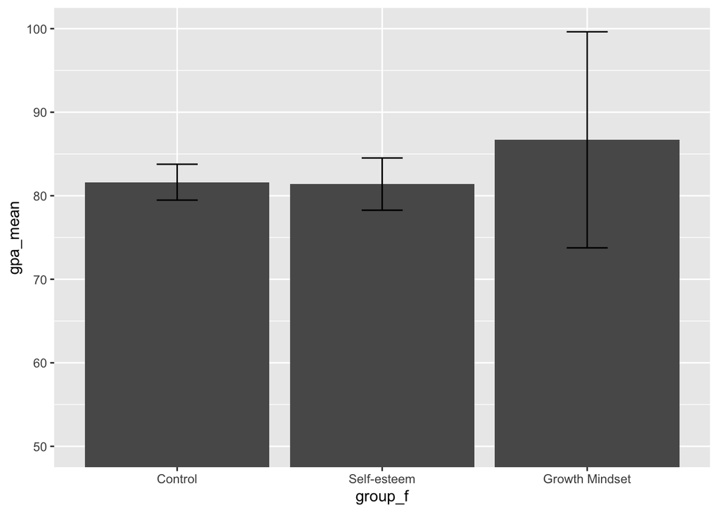

```r
gm_means %>%
  ggplot(aes(x = group_f, y = gpa_mean)) +
  geom_col() +
  geom_errorbar(aes(ymin=gpa_mean-gpa_sd, ymax=gpa_mean+gpa_sd), width=.2) +
  coord_cartesian(ylim = c(50, 100))
```

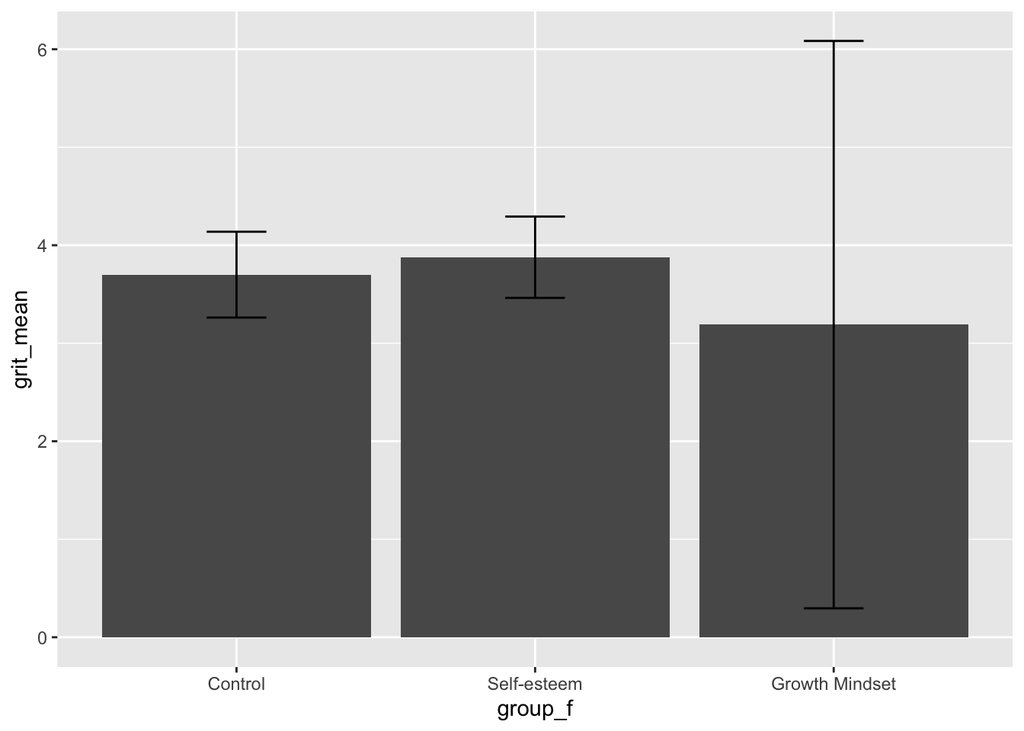

```r
gm_means %>%
  ggplot(aes(x = group_f, y = grit_mean)) +
  geom_col() +
  geom_errorbar(aes(ymin=grit_mean-grit_sd, ymax=grit_mean+grit_sd), width=.2)
```

The plot thickens. Well, the plots didn’t literally thicken, but you know what I mean lolz. Adding error bars reveals that there is huge variability in both the GPA and grit estimates for the growth mindset group. Like, wut? What does this mean?

Well, it could mean that there is naturally way more variability in the growth mindset group across outcomes–rotten luck. That would mean that we failed to randomize the groups properly, and there *were* baseline differences across groups. When you randomize, you want all groups to be equal across everything–except what you’re manipulating (i.e. the intervention).

It could also mean that the growth mindset intervention is helpful for some, and hurtful for others, and that there is some moderating factor that determines whether it’s good or bad. This would also not be ideal–like I said, we don’t want our interventions to *ever* be hurtful. We are starting to get a picture of the complexity of statistics - math can be subjective!

But, there’s one other possible explanation: outliers. How could outliers be a problem? And what is an outlier?

# 3 Outliers

## 3.1 What is an outlier?

**An outlier is a response (aka data point) that is so far away from the majority of responses for a population or variable that it is considered extreme.**

## 3.2 What’s the problem with outliers?

Is that such a bad thing? Why can’t we just leave outliers alone to live their life of solitude on the edges of our data?

Here are 3 problems outliers can create:

1. **They bias or influence estimates of analyses**. This can be especially problematic if they substantially influence answers to questions of interest.
2. **They increase error variance and reduce statistical power** (aka your likelihood of finding an effect if there is really one there).
3. **They can change the odds of making both [type I and type II errors](https://www.simplypsychology.org/type_I_and_type_II_errors.html)**. (See [this paper](https://scholarworks.umass.edu/cgi/viewcontent.cgi?article=1139&context=pare) for an example.)

How do they do all of these horrible things?

Let’s look at an example. Run the chunk below and look at the graph. We have 6 data points, with their average represented with the red dot and one standard deviation above and below the mean represented by the red line. Because these data are balanced, the mean represents the typical response of the data, and the standard deviation represents the typical spread perfectly.

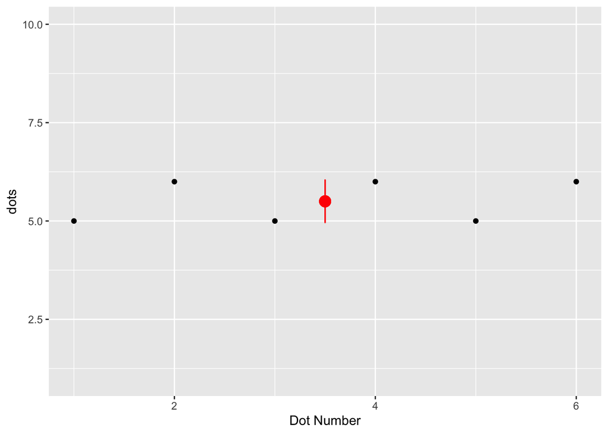

```r
dots <- c(5, 6, 5, 6, 5, 6)
num <- c(1, 2, 3, 4, 5, 6)
dotsnum <- cbind.data.frame(dots, num)

dotsnum %>% ggplot() +
  geom_point(aes(x = num, y = dots)) + coord_cartesian(ylim = c(1, 10))+
  geom_point(aes(x = mean(num), y = mean(dots)), colour="red", size = 4) + xlab("Dot Number")+
  geom_errorbar(aes(x = mean(num), y = mean(dots), ymin = mean(dots)-sd(dots), ymax = mean(dots)+sd(dots)), width = .001, color = "red")
```

But what happens if one of the responses is far away from the others?

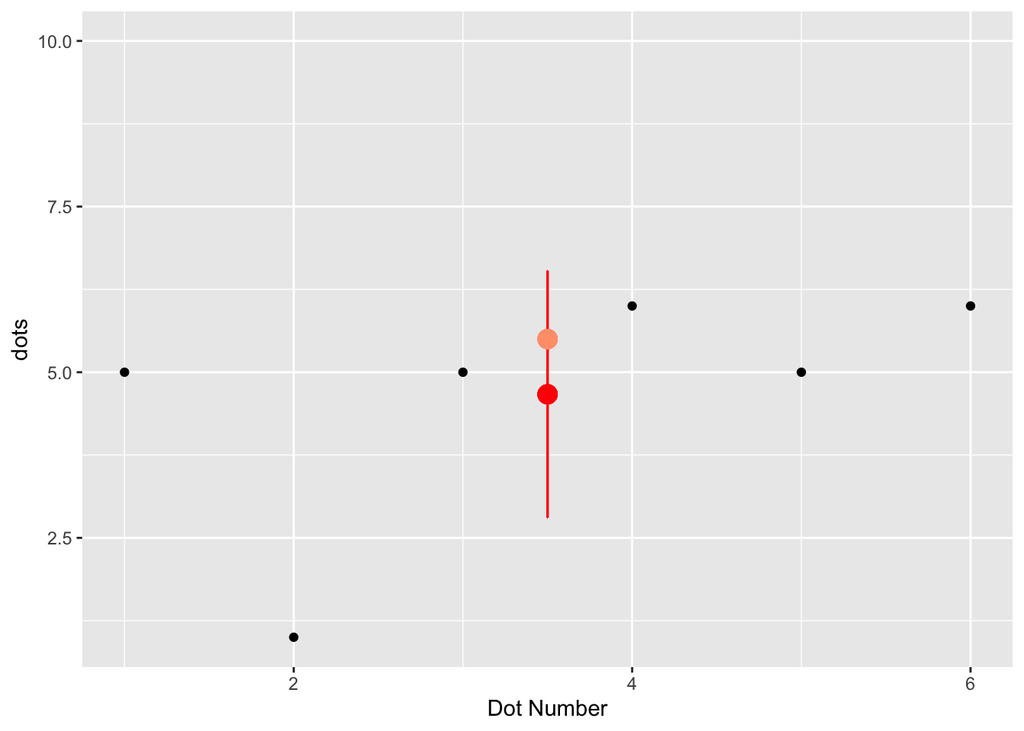

```r
dots <- c(5, 1, 5, 6, 5, 6)
num <- c(1, 2, 3, 4, 5, 6)
dotsnum <- cbind.data.frame(dots, num)

dotsnum %>% ggplot() +
  geom_point(aes(x = num, y = dots)) + coord_cartesian(ylim = c(1, 10))+
  geom_point(aes(x = mean(num), y = mean(dots)), color="red", size = 4) + xlab("Dot Number") +
  geom_errorbar(aes(x = mean(num), y = mean(dots), ymin = mean(dots)-sd(dots), ymax = mean(dots)+sd(dots)), width = .001, color = "red") +
  geom_point(aes(x = mean(num), y = 5.5), color="lightsalmon1", size = 4) #+
```

```r
  #geom_errorbar(aes(x = mean(num), y = 5.5, ymin = 5, ymax = 6), width = .001, color = "lightsalmon1")
```

Oh my - that was a prrrrrrrretty devastating change!

Now, we can see that the new mean has been weighted toward the outlying response, and no longer represents the typical response, indicated by the lighter red (or more specifically “lightsalmon1”) dot that is the mean from the last graph. Even more, the standard deviation is inflated and no longer represents the typical spread of the data, either.

What does this tell us? Outliers disproportionately influence these estimates of central tendency and spread, skewing and inflating them much more than the addition of one “normal” data point would.

Practically speaking, this means that if we have outliers, then:

1. averages and estimates of relationships (e.g. correlation/regression) will be skewed from the true average or estimate of the underlying population and
2. measures of variance (including standard deviations and standard errors) will be inflated, making our estimates much less precise, and making it much more difficult to find an effect.

## 3.3 Where do outliers come from?

When we collect data and run analyses, we are sampling (aka taking a few people) from a larger population that we’d like to study. Outliers are problematic in part because they don’t accurately represent the population we would like to study, and therefore make it more difficult to get accurate and precise estimates of what is true for that population, on average.

## 3.4 Univariate outliers

Now that we’ve learned a little bit about outliers and why they may be problematic, how might this apply to our earlier problem with our growth mindset intervention?

The presence of outliers seems like a reasonable explanation for our problems. If you remember, our data had unexpected means and inflated standard deviations. If outliers are the culprit, then we might expect that they come from data entry errors; people we didn’t mean to sample; or extreme, but legitimate responses. (Not legit, kinda legit, and legit!!!)

Let’s check it out.

At the most basic level, we can check for outliers using boxplots. Because we noticed abnormalities in the outcomes (`grit` and `gpa`) across intervention groups, let’s plot boxplots for the outcomes across groups.

Boxplots identify outliers with dots beyond the common range of values. Looking at these can show us quickly if there seem to be any extreme scores.

What do you see?

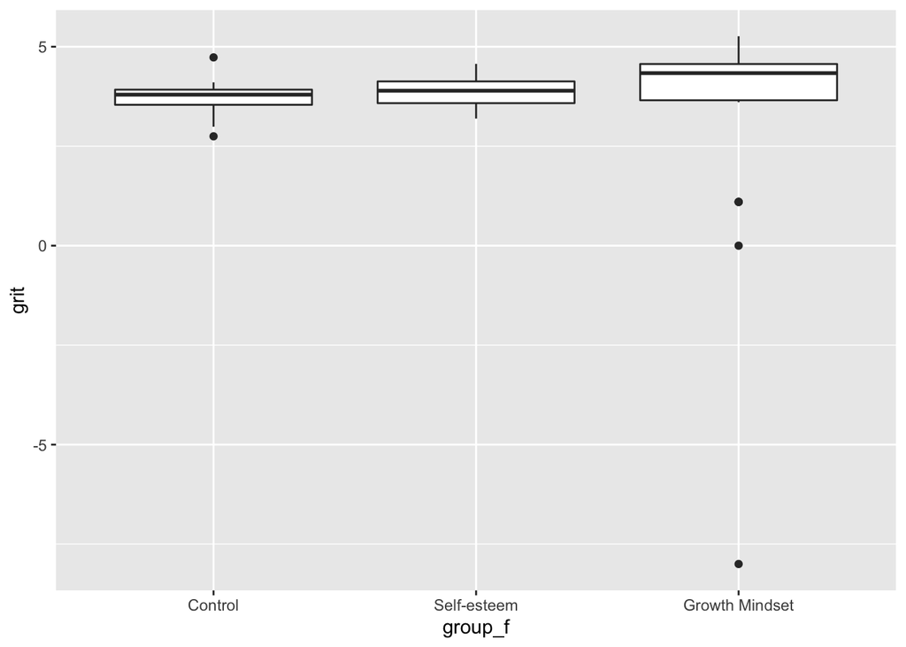

```r
gm %>% ggplot() +
  geom_boxplot(aes(x = group_f, y = grit))
```

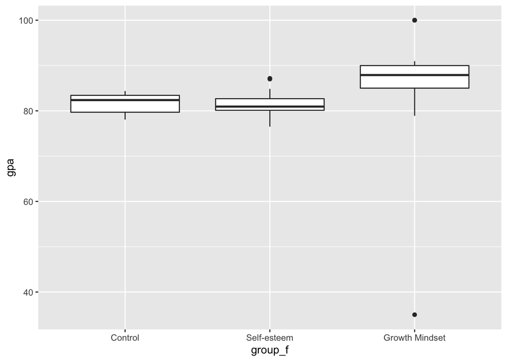

```r
gm %>% ggplot() +
  geom_boxplot(aes(x = group_f, y = gpa))
```

Because we know that the range of possible values for grit is 1 - 5, there may be a couple of out-of-bounds responses for grit that are causing problems.

Also, because the range for gpa is 50 - 100 (these schools don’t give grades below 50), then it looks like there is an out-of-bounds value for gpa, too. We can quickly see which values might be out-of-bounds using `dplyr`s ever useful `filter` function:

```r
gm %>% select(id, grit) %>% filter(grit < 1)
```

```
##    id grit
## 1 304    0
## 2 305   -8
```

```r
gm %>% select(id, gpa) %>% filter(gpa < 50)
```

```
##    id gpa
## 1 302  35
```

It looks like our suspicions were correct, and there are two out-of-bounds values for grit and one for gpa. Because these are most likely data entry errors and not legitimate responses, we will not consider them in our analyses, and can essentially “delete” them. We will do this by coding them as missing (`NA` in R means missing). We can do so by recoding our variables to code as missing any values that are out-of-bounds.

```r
#the function ifelse() works like this: ifelse(if_condition, then_do_this, otherwise_do_this). So here, the first one would be read as: "if grit is less than one, than code as missing, otherwise code the same as the original grit variable".

gm2 <- gm %>% mutate(

  grit = ifelse(grit < 1, NA, grit),
  gpa = ifelse(gpa < 50, NA, gpa)

)
```

Now that we have removed the data errors, let’s look at the boxplots again:

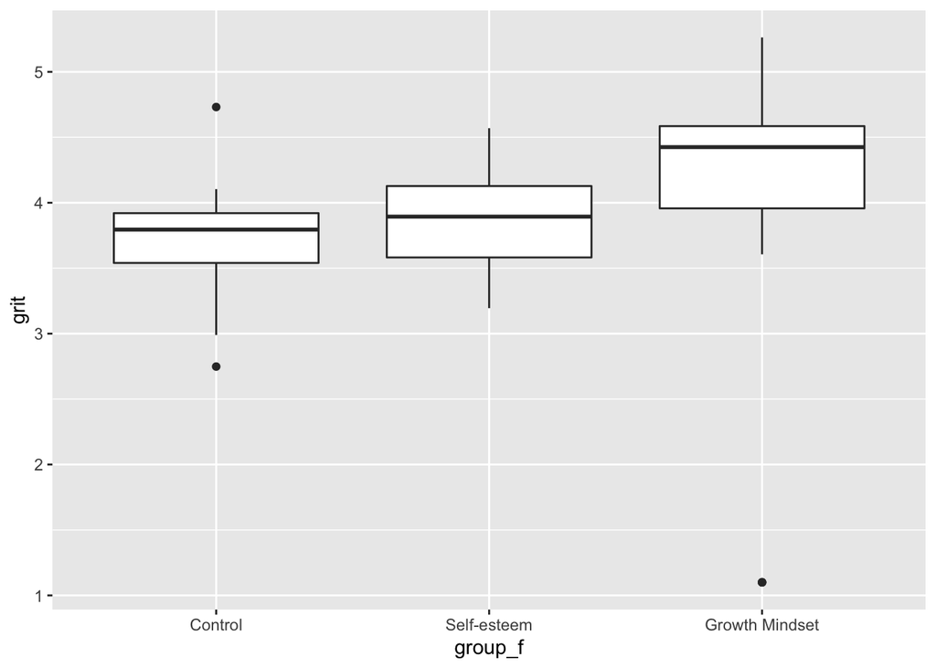

```r
gm2 %>% ggplot() +
  geom_boxplot(aes(x = group_f, y = grit))
```

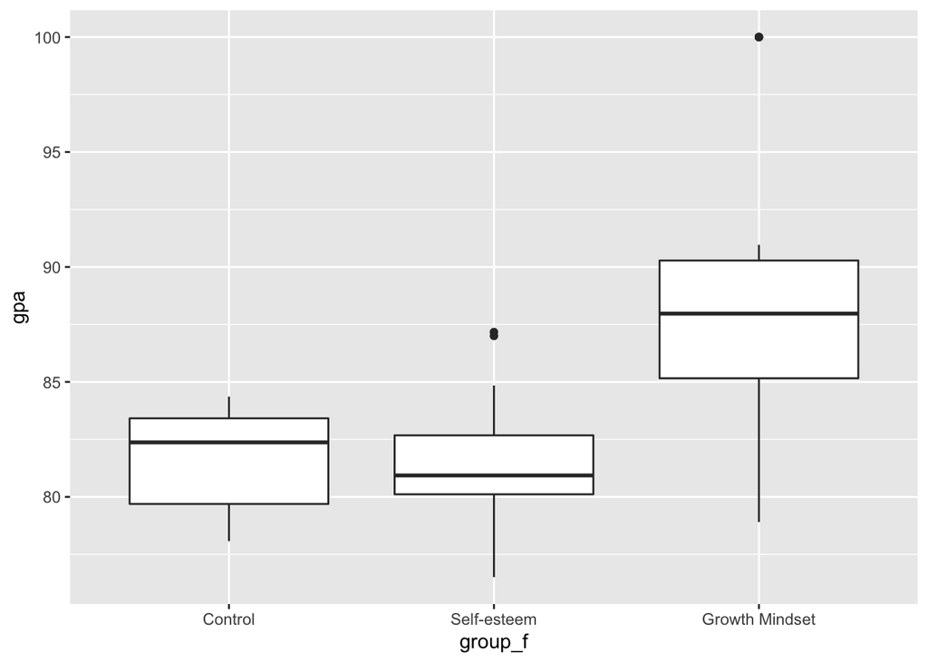

```r
gm2 %>% ggplot() +
  geom_boxplot(aes(x = group_f, y = gpa))
```

Ugh, sooo much better, but still not perfect! It looks like there still might be a few outliers. because we have already dealt with suspected data entry errors, we will assume that the remaining outliers are legitimate, but extreme responses. At this point, unfortunately, it’s difficult to tell what causes these outliers, so we will treat them all the same. Note, in this case, if they’re “legit” and being academically rigorous, we might just want to leave them! However, for the sake of pedagogy here, we will remove them.

To deal with these outliers, we’ll use one of the most basic (and conservative) methods for dealing with outliers: the z-score method.

FYI: there are a ton of ways to deal with outliers!

The z-score method excludes any values above or below 3 standard deviations from the mean. To do this, the first step is to identify if there are any values beyond this threshold. `filter`, again, is a great way to do this:

```r
gm2 %>%
  select(id, gpa) %>%
  mutate(z_gpa = scale(gpa)) %>%
  filter(z_gpa>=3| z_gpa<=-3)
```

```
## [1] id    gpa   z_gpa
## <0 rows> (or 0-length row.names)
```

```r
gm2 %>%
  select(grit) %>%
  mutate(z_grit = scale(grit)) %>%
  filter(z_grit>=3 | z_grit<=-3)
```

```
##   grit    z_grit
## 1  1.1 -3.292483
## 2  1.1 -3.292483
## 3  1.1 -3.292483
```

It looks like there are 3 values of grit that are more than 3 standard deviations below the mean (scale(grit) < -3). Using the code below, let’s recode those values to be missing.

```r
gm2.no.out <- gm2 %>% mutate(

  grit = ifelse(scale(grit) < -3,
                NA,
                grit)

)
```

Now that we’ve taken care of outliers, let’s look at the effect of the intervention on `grit` and `gpa` again.

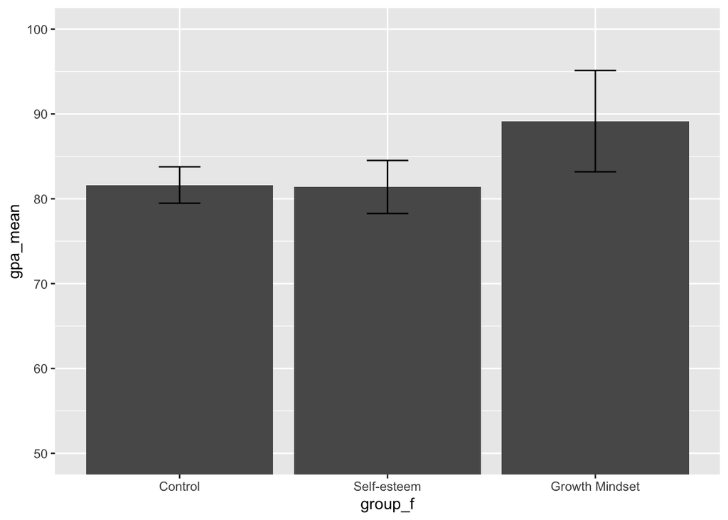

```r
gm_means <- gm2.no.out %>%
              group_by(group_f) %>%
                summarise(gpa_mean = mean(gpa, na.rm = TRUE),
                          gpa_sd = sd(gpa, na.rm = TRUE),
                          grit_mean = mean(grit, na.rm = TRUE),
                          grit_sd = sd(grit, na.rm = TRUE))

gm_means %>%
  ggplot(aes(x = group_f, y = gpa_mean)) +
  geom_col() +
  geom_errorbar(aes(ymin=gpa_mean-gpa_sd, ymax=gpa_mean+gpa_sd), width=.2) +
  coord_cartesian(ylim = c(50, 100))
```

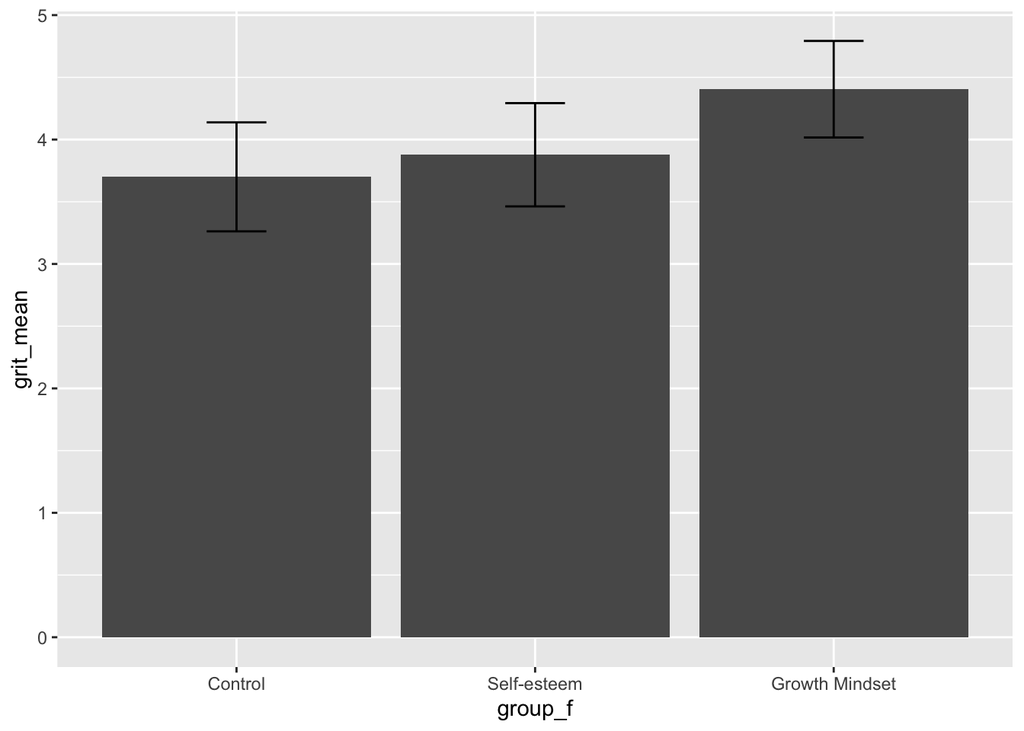

```r
gm_means %>%
  ggplot(aes(x = group_f, y = grit_mean)) +
  geom_col() +
  geom_errorbar(aes(ymin=grit_mean-grit_sd, ymax=grit_mean+grit_sd), width=.2)
```

We can see that removing outliers significantly increased the average score of grit in growth mindset condition. Also, the variability in both gpa and grit is much lower. Removing outliers helped correct skewed means and make estimates of variability more precise.

## 3.5 Multivariate outliers

When you have a larger dataset, using univariate outliers can get annoying quickly.BTW, univariate just means one variable (one X), and multivariate means more than one X! Scanning each variable takes a lot of time - Even if you wrote code to do it faster, you might end up eliminating too much data.

What happens if we want to see if there are outliers on more than variables? Well, we could give up immediately and we wouldn’t be able to visualize it well, because there isn’t a good way to graph anything larger than 3 dimensions. We definitely can’t just take the z-score, because we don’t *have* a z-score that takes into account more than one dimension… If we could only compute some sort of measurement that tells us how different a person’s overall response is compared to everyone else… Wait! We do have something *like* a z-score that works for many dimensions: Mahalonobis distance. Try to say that 10 times fast!!!

Mahalonobis distance is doing essentially the same thing as a z-score: taking an average and computing how far away something is from that average. Like a z-score, things that are very far away would be considered outliers. However, instead of looking at the average of a *single variable*, like a z-score, Mahalonobis distance assesses the average *pattern of responses* across many variables, and subsequently computes the distance of each individual’s pattern of response from the average pattern.

Mahalanobis distances also solve one issue of working with multiple variables: The correlation problem. Why would correlation be a problem in outlier detection? See the following plot:

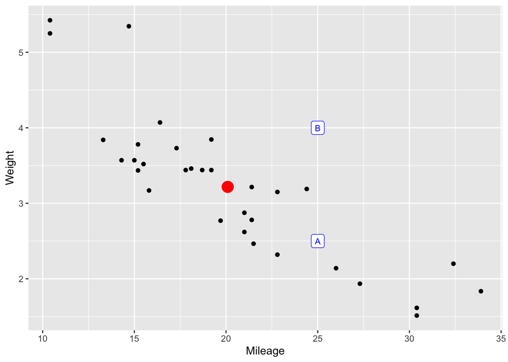

Check out Points A and B. They are the *same distance* from the mean of weight and mileage (About an inch, using my ruler, or 2.2 cm because metric is cool), yet, point B is much more likely an outlier than point A. That’s because, in order to accurately calculate multivariate outliers, we need to take into account the correlation between weight and mileage. You know? that downward trend with weight decreasing as mileage increases that you inevitably noticed because you’re smart ;)

This is essentially what Mahalanobis Distances are doing with as many variables as you would like to include. They are comparing each of the rows in your data set (each survey response, for example), with everybody else’s responses. Taking correlation into account, it generates one number that represents how far away that response is from all others.

PS: If you thought this was *incredibly interesting*, you’re insane, but [here](https://www.youtube.com/watch?v=spNpfmWZBmg) is a youtube video going into more detail.

### 3.5.1 How do we compute multivariate outliers?

We can then test these distances for statistical significance; in line with a common standard of Mahalonobis distances, we’ll say anyone whose distance is a .001 probability of occurring an outlier. In this sense, we are thinking of outliers probabilistically instead of just in terms of Euclidean Distance.

This is exactly what this custom function (`MO_Detection`) is doing:

1. Generates a mean vector and a covariance matrix (think correlation matrix) from the data
2. Inputs those to generate a vector of Mahalanobis distances
3. Calculates what the cutoff would be to exclude cases where the distance is p < .001, using the chi-squared distribution and the number of variables
4. Returns a plot and a data frame without the outliers.

This whole procedure and function was inspired and adapted from [this video](https://www.youtube.com/watch?v=zL66kiX5VZg&t=948s). (Thanks Dr. Buchanan!)

```r
MO_Detection = function (CompleteDataset, AnalyzedDataset, alpha = 0.001) {
  Means = colMeans(AnalyzedDataset, na.rm = T)
  Covariance = cov(AnalyzedDataset, use = "pairwise.complete.obs")
  Distances = mahalanobis(AnalyzedDataset, Means, Covariance)
  cutoff = qchisq(1-alpha, ncol(AnalyzedDataset))
  remain = Distances < cutoff
  PlotData = AnalyzedDataset %>%
    mutate(ID = 1:nrow(AnalyzedDataset),
           Distance = Distances,
           Outlier = factor(remain,labels = c("Yes","No")))
  n = nrow(AnalyzedDataset) - sum(remain)
  report = paste(n, "cases were multivariate outliers")
  print(report)
  p = ggplot(PlotData, aes(ID, Distance, color = Outlier)) +
    geom_point() +
    labs(title = "Multivariate Outliers",
         subtitle = report)
    theme(legend.position = "bottom")
  print(p)

  return(CompleteDataset %>% filter(remain))
}
```

Please don’t worry if you don’t understand that function. All that really matters is that you can run the next cell and comprehend the output. I apologize for the complexity! Life is hard. The output is easy. Someday, it’ll all just be over as the dark nothingness takes us all eventually… I kid, I kid. Kind of.

Let’s try removing multivariate outliers from our Growth Mindset Intervention Study. The `MO_Detection` function takes as input the complete dataset, the dataset with the variables we’ll use (only numeric variables), and the alpha level.

```r
gm_noout = MO_Detection(gm, gm[7:9],alpha =.5)
```

```
## [1] "16 cases were multivariate outliers"
```

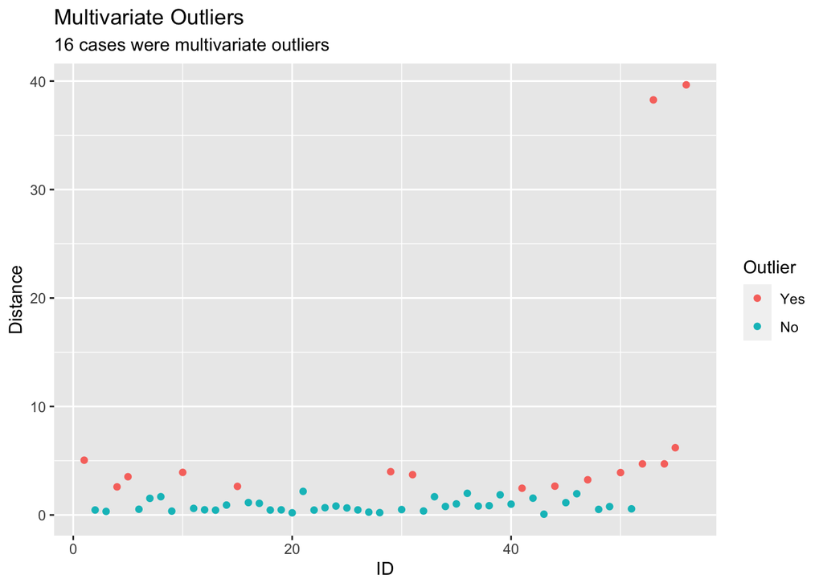

Explore: Try changing the alpha value to something even more improbable (say 0.001), or more probable (say .80) and see how changing that parameter affects how many values are classified as outliers. (Note that .001 is customary).

```r
gm_noout = MO_Detection(gm, gm[7:9],alpha = 0.01)
```

```
## [1] "2 cases were multivariate outliers"
```

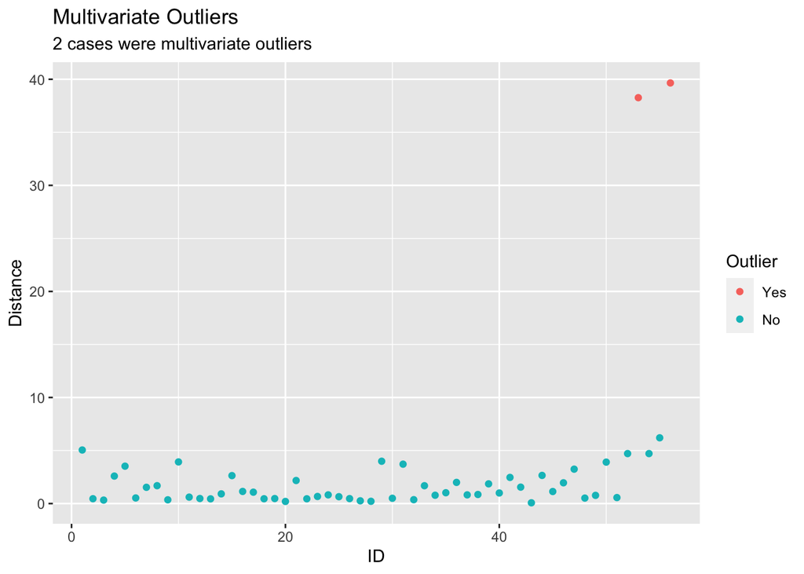

```r
#gm_noout = MO_Detection(gm, gm[7:9],alpha = 0.8)
```

Okay, this next section is harder and more specifically digs into psych stats. It will be difficult to conceptualize at first, but if you hope to a be psychologist - you will need to learn this material. In the future, you can save this markdown to use as a reference :)

# 4 Reliability

After we take care of outliers, another very important issue is measurement, what we call **psychometrics**. One of the most important psychometric properties of our data is reliability.

For reliability discussion today, let’s talk (and learn how to compute) Cronbach’s Alpha. Does anyone else think that Cronbach sounds like an old person who gives out butterscotch candy, please let me know. I mean, it does. Just please agree with me.

In psychology, we often use self-report scales with multiple items; create composites of those scales; and measure “reliability” of those scales using Cronbach’s Alpha. However, most people have a hard time articulating what Cronbach’s Alpha *actually* means. What is Cronbach’s Alpha actually measuring? What does it mean to be “reliable”? How do you compute Cronbach’s alpha in R? And how do you interpret it?

Let’s dive in.

First, what is Cronbach’s Alpha actually measuring?

Let’s look at an example that might help.

First, load in the data. Also, if you haven’t already, load in the package `psych`.

```r
gm.full <- read.csv("growth mindset study.csv")

library(psych)

view(gm.full)
```

For simplicity, let’s only keep the variables that we will be using for our alpha calculation: grit items. One slick way to do this is to use `select` from `dplyr` in conjunction with the helper function `starts_with()`:

```r
gm.full %<>% select(starts_with("grit"))
```

I’ll give you one guess as to what `starts_with()` does…. you got it! I’m assuming you got it.

Computing Cronbach’s alpha in R is simple. Just use the function `alpha` from the `psych` package, and insert your data you want analyzed as the argument. Here, let’s save the output as an object called `grit.a`, then take a look.

```r
grit.a <- alpha(gm.full)
```

```
## Number of categories should be increased  in order to count frequencies.
```

```r
grit.a
```

```
##
## Reliability analysis
## Call: alpha(x = gm.full)
##
##   raw_alpha std.alpha G6(smc) average_r S/N    ase mean   sd median_r
##        0.9       0.9    0.88       0.7 9.3 0.0091  3.9 0.62      0.7
##
##  lower alpha upper     95% confidence boundaries
## 0.89 0.9 0.92
##
##  Reliability if an item is dropped:
##       raw_alpha std.alpha G6(smc) average_r S/N alpha se   var.r med.r
## grit1      0.87      0.87    0.81      0.69 6.6    0.013 1.3e-04  0.68
## grit2      0.88      0.88    0.83      0.71 7.2    0.012 9.7e-04  0.70
## grit3      0.88      0.88    0.83      0.71 7.2    0.012 1.0e-03  0.70
## grit4      0.87      0.87    0.82      0.70 7.0    0.013 2.0e-06  0.70
##
##  Item statistics
##         n raw.r std.r r.cor r.drop mean   sd
## grit1 300  0.89  0.89  0.84   0.80  3.9 0.73
## grit2 300  0.87  0.87  0.81   0.77  3.9 0.68
## grit3 300  0.87  0.87  0.81   0.77  3.9 0.69
## grit4 300  0.88  0.88  0.83   0.78  3.9 0.72
```

YIKES!!!!!!–that’s a lot to look at, and we don’t even know what 95% of it means! We want the raw alpha:

```r
grit.a$total$raw_alpha
```

```
## [1] 0.9030008
```

Was that helpful? probably not - let’s dive in!

## 4.1 What is alpha actually measuring? How do you compute alpha?

WARNING - because of some formatting, I would implore you to read through the HTML markdown for this section. The formula in between the `$` will look lovely and pretty online, but will be hard to read here. The one hack is to hover your mouse over the formula and it “should” give you a preview if your R is up to date!

It’s actually pretty simple. Here’s the formula for Cronbach’s alpha:

$\frac{k\bar{r}}{1+(k - 1)\bar{r}}$

where:

- k = the number of items
- $\bar{r}$ = the average inter-item correlation

That’s not so hard–it really only needs two numbers to work. But what exactly is the “average inter-item correlation”?

Here’s an explanation: Take the first item of our scale, “grit1”, correlate it with each other item–“grit2”, “grit3”, and “grit4”–and average those correlations, and we have the average inter-item correlation for “grit1”. If we then take the average inter-item correlation *for each item* and average those together, we get the average inter-item correlation for the scale, what we are calling here $\bar{r}$.

To put it into words, computing Cronbach’s alpha is **multiplying** the number of items **by** the average inter-correlation among those items **divided by** the total variance in the composite–all of the items together.

So, we could say Cronbach’s alpha is **the proportion of the total variance of the items that is explained across items, or varies together across items**.

This is one of those things where I would be SHOCKED if you understood it completely based on one mediocre written out explanation. If you do get it **BRAVO** - I did not. Please come with questions to our next group session and we will go over it more. Cronbach’s alpha is a large part of statistics in psychology and while it is not essential that you understand it for learning R, it is essential to understand as a future psychologist!

Now, let’s try it ourselves and see if we get the same value as the `alpha` function.

First: we can let `alpha` do some of the work for us–from the output we can extract the average inter-item correlations.

```r
rbar <- grit.a$total$average_r
```

Second: We have 4 items, so we’ll set k = 4. (`View()` the data set if you are unclear)

```r
k <- 4
```

Third: plug those values into the formula

```r
alpha.by.hand <- (k*rbar)/(1+(k - 1)*rbar)

alpha.by.hand
```

```
## [1] 0.903152
```

Great, we were able to get the result: a = .90! This means that among the total variation in the scores, 90% of the variance is explained by the items in the scale varying together.

And what exactly does it mean to vary together? Really it just means to correlate: when one goes up, the other goes up; when one goes down, the other goes down.

## 4.2 What is a “good” alpha?

The standards for the field (though somewhat arbitrary) are clear: a = .70 is acceptable, a = .80 is good, and a = .90 is great. Anything under a = .65 will generally require a strong rationale for why that level of inconsistency is acceptable. Does this seem kind of subjective to you? Yes!! But that is the social sciences. There is so much weird variability in measuring human behavior that we have to accept lower values of reliability as scientifically valid. In physics for example, statistical significance often requires p-values of like 0.0001.

## 4.3 In sum, what is alpha?

So, Cronbach’s alpha is a measure of **consistency of responses** in the data among the items of a scale.

The smaller the shared variance is, the higher the error variance, or unexplained variance is. This means that unaccounted variation is playing a bigger part in the measure (if the items are combined), introducing more random noise and *inconsistency*. Herein, as error variance increases, the composite will be *a less consistent* measure.

## 4.4 In sum what is alpha not?

I know, that was a grammatically tough header, but here’s some further explanation!

Alpha is:

- **NOT A measure of reliability of the scale**. This is a little nitpicky, but alpha is not a measure of reliability of the scale, it is a measure of the reliability (consistency) of responses in *your data*. Why does that matter? That matters because it means that Cronbach’s alpha is expected to vary across data sets–it shouldn’t (necessarily) be perfectly consistent across data sets because correlations between items will vary. Rather, it is a measure of the consistency of your responses and should be computed for each data set.
- **NOT a measure of unidimensionality**. High alpha does not imply unidimensionality. Actually, multidimensional data can still have an adequate alpha, but on the flip side, Cronbach’s alpha does *assume* unidimensionality, and thus should not be performed on multidimensional data.
- **NOT an indication that your items are highly correlated**. Importantly, alpha is heavily influenced by number of items as well as correlation strength. For example, 60 items correlated at an average of r = .07 will have an alpha of .83. Another example: we might consider an alpha of .73 acceptable, but for a scale of 5 items, this would mean an average inter-item correlation of only r = .35. Acceptable alpha does not imply high inter-item correlation.
- **NOT justification for combining scale items into a composite**. Factor analysis is better suited for this as it determines underlying factors in the data and gives estimates of the amount of information retained in a composite score from the constituent items.

Please take a break her! We are gonna get into more new stuffs! I knowwwww Ben is making us learn so much psych stuff. It’s okay - shoot him an email if you need help. This may *seem* esoteric, but it’s a big part of psych!! YOU GOT THIS AGHHHHHH

# 5 Factor analysis

NOTE: If you want a comprehensive walkthrough of factor analysis, check out this youtube video [here](https://www.youtube.com/watch?v=EKpYh7lsOf8). It’s over an hour long, but it’s excellent and will help you understand beyond what I have written below! This stuff is challenging - I’ll admit it right now.

So far, we’ve been happily creating composites from items (averaging items, summing items, etc.), without putting too much thought into important questions:

- ```
  Are all these questions related enough to justify adding them together?
  ```

- ```
  Should we add all the items together into a single composite or should we create more composites?
  ```

- ```
  Are all items working properly, or are there some that are not working well?
  ```

- ```
  If we are summarizing ten columns (for ten items), into one (for the composite), how much information are we loosing?
  ```

Now you’re thinking like a true scientist! asking the big questions ;)

Factor analysis, and related techniques, help us answer all of these BIG questions.

Let’s start by loading our data.

```r
sps <- read_csv("Confidence in Science.csv")
view(sps)
```

If you didn’t, go ACTUALLY LOOK AT THE DATA! We want to combine allll that info into a single measure of “confidence in science”. Pretty nuts that we can do this with math! And do a pretty good job!!!

The data (this time it’s real), asks participants for their perception of efficacy of scientific (e.g. medicine) and pseudoscientific practices (e.g. Tarot).

Say we want to work with a smaller number of variables (rather than the full 13), and we think these items represent one or two underlying constructs. Factor analysis will help us make those decisions and justify how we make our composites.

Most likely the items will form a single factor. A continuum starting in complete belief in science and disregard for pseudoscience, and ending in the opposite, people who distrust the scientific establishment in favor of more ‘alternative methods’

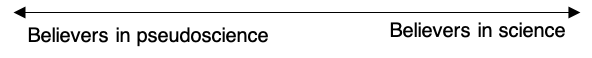

Fig 1. A single factor

Here are the steps

## 5.1 Are the items correlated enough to warrant a composite?

The first condition is that the items need to be correlated enough to justify adding some of them together. It makes sense to add related items (“Are you happy”, “Are you cheerful”) but you wouldn’t add unrelated items (“I like to keep stuff in order”).

Let’s see how correlated our items are. The following code is a big box that shows ever variables correlation with another variable.

Question: Why are some of the correlations 1?

```r
sps %>% cor() %>% round(2)
```

```
##                            Psychiatry Astrology Medicine Psychotherapy
## Psychiatry                       1.00      0.07     0.66          0.46
## Astrology                        0.07      1.00    -0.06          0.23
## Medicine                         0.66     -0.06     1.00          0.46
## Psychotherapy                    0.46      0.23     0.46          1.00
## ForensicSeers                    0.04      0.69    -0.03          0.22
## MagnetTherapy                    0.09      0.67    -0.05          0.22
## NeuroLinguisticProgramming       0.14      0.41     0.13          0.26
## Tarot                            0.03      0.75    -0.10          0.16
## Numerology                       0.02      0.75    -0.11          0.17
## BachFlowerRemedies               0.04      0.64    -0.05          0.22
## Homeopathy                       0.03      0.60    -0.04          0.19
## Reiki                            0.04      0.65    -0.01          0.22
## Vaccines                         0.58     -0.12     0.74          0.38
##                            ForensicSeers MagnetTherapy
## Psychiatry                          0.04          0.09
## Astrology                           0.69          0.67
## Medicine                           -0.03         -0.05
## Psychotherapy                       0.22          0.22
## ForensicSeers                       1.00          0.65
## MagnetTherapy                       0.65          1.00
## NeuroLinguisticProgramming          0.46          0.53
## Tarot                               0.62          0.58
## Numerology                          0.65          0.67
## BachFlowerRemedies                  0.58          0.67
## Homeopathy                          0.56          0.66
## Reiki                               0.55          0.72
## Vaccines                           -0.06         -0.06
##                            NeuroLinguisticProgramming Tarot Numerology
## Psychiatry                                       0.14  0.03       0.02
## Astrology                                        0.41  0.75       0.75
## Medicine                                         0.13 -0.10      -0.11
## Psychotherapy                                    0.26  0.16       0.17
## ForensicSeers                                    0.46  0.62       0.65
## MagnetTherapy                                    0.53  0.58       0.67
## NeuroLinguisticProgramming                       1.00  0.38       0.47
## Tarot                                            0.38  1.00       0.75
## Numerology                                       0.47  0.75       1.00
## BachFlowerRemedies                               0.51  0.60       0.61
## Homeopathy                                       0.53  0.54       0.59
## Reiki                                            0.49  0.59       0.61
## Vaccines                                         0.09 -0.11      -0.13
##                            BachFlowerRemedies Homeopathy Reiki Vaccines
## Psychiatry                               0.04       0.03  0.04     0.58
## Astrology                                0.64       0.60  0.65    -0.12
## Medicine                                -0.05      -0.04 -0.01     0.74
## Psychotherapy                            0.22       0.19  0.22     0.38
## ForensicSeers                            0.58       0.56  0.55    -0.06
## MagnetTherapy                            0.67       0.66  0.72    -0.06
## NeuroLinguisticProgramming               0.51       0.53  0.49     0.09
## Tarot                                    0.60       0.54  0.59    -0.11
## Numerology                               0.61       0.59  0.61    -0.13
## BachFlowerRemedies                       1.00       0.77  0.75    -0.04
## Homeopathy                               0.77       1.00  0.80    -0.03
## Reiki                                    0.75       0.80  1.00    -0.01
## Vaccines                                -0.04      -0.03 -0.01     1.00
```

Answer: An item is always perfectly correlated with itself DUHHHHHHHHH. Sorry if that sounded condescending I promise it wasn’t. Think of it more as a Homer Simpson ‘DOPE’.

We can see several high correlations on the correlation matrix.

There are two tests that we can use to analyze how good the correlations are. One of them is Keyser, Meyer, and Olkin’s sample adequacy statistic (KMO for short), and the other is Bartlett’s Sphericity test.

Let’s start with KMO.

```r
KMO(sps)
```

```
## Kaiser-Meyer-Olkin factor adequacy
## Call: KMO(r = sps)
## Overall MSA =  0.9
## MSA for each item =
##                 Psychiatry                  Astrology
##                       0.80                       0.92
##                   Medicine              Psychotherapy
##                       0.71                       0.91
##              ForensicSeers              MagnetTherapy
##                       0.94                       0.93
## NeuroLinguisticProgramming                      Tarot
##                       0.94                       0.91
##                 Numerology         BachFlowerRemedies
##                       0.93                       0.94
##                 Homeopathy                      Reiki
##                       0.90                       0.90
##                   Vaccines
##                       0.76
```

We can see that overall KMO is .90 (which is good - don’t worry too much about specific values), and individual item KMOs are also above .7, which is also good. Here are some interpretation guidelines for KMO.

- .00 to .49 unacceptable.
- .50 to .59 miserable.
- .60 to .69 mediocre.
- .70 to .79 middling.
- .80 to .89 meritorious.
- .90 to 1.00 marvelous.

Yes, those are the actual adjectives used in the original guidelines! However, they are subjective measures. Don’t forget the cruel irony of statistics being math, yet subjective!!!!

Bartlett’s sphericity test compares the correlation matrix to an identity matrix (one where all correlations are 0). Let’s see how that goes. It’s kind of like an F-test with correlations - if that makes more intuitive sense.

```r
psych::cortest.bartlett(sps)
```

```
## R was not square, finding R from data
```

```
## $chisq
## [1] 2770.09
##
## $p.value
## [1] 0
##
## $df
## [1] 78
```

Bartlett’s sphericty test shows that there *are* correlations ($\chi^2 = 2770.09$ [78, $n = 316$ ],$p < .001$). in English, the chi-square is big, which means we want to extract the factors. Once again, I know this is confusing and fast, but if someone ever asks you about factor analysis, you can just get out this mark down and cheat a little ;)

Now, with that out of the way, our next question is: How many factors should we extract?

Actually, there’s something else we should do first.

Why was the stadium so hot….?

All the fans left!!

teeeeheeeeeeeee.

## 5.2 How many factors?

There is no set answer to this question but there are a couple of useful techniques.

One of the most common (it’s the default in SPSS) is to extract as many factors as have eigenvalues greater than one. What’s an eigenvalue? I’m going to ignore that question because it basically requires a full course in linear algebra to explain. However, you can still run this R code and look at the outputs to see if they’re bigger than one! I generally don’t advocate you to do math you can’t understand, but for the sake of using R to do psych stats. We shall let it slide. No joke - just ignore eigenvalues. They are basically a special “multiplier” for data sets.

Let’s see what happens:

```r
sps %>% cor %>% eigen(only.values = T)
```

```
## $values
##  [1] 6.0272142 2.6976646 0.8233473 0.6072636 0.5879261 0.4274641 0.4043967
##  [8] 0.3196233 0.2665481 0.2414641 0.2236422 0.2070060 0.1664397
##
## $vectors
## NULL
```

We can see that there are two factors with eigenvalues greater than one. According to this method, we should then extract two factors.

A related technique plots these eigenvalues and uses a more visual approach. Look for a point of inflection, where the line goes from vertical to horizontal. This will yield the optimal number of factors to extract. This is based on the principle of *diminishing marginal returns*. The first eigenvalue always explains a lot of variance, and the following ones explain less and less. The inflection point can be understood as the point of optimum balance between information loss (i.e. keeping as much information as possible) and efficient compression (i.e. doing that in the least number of factors possible).

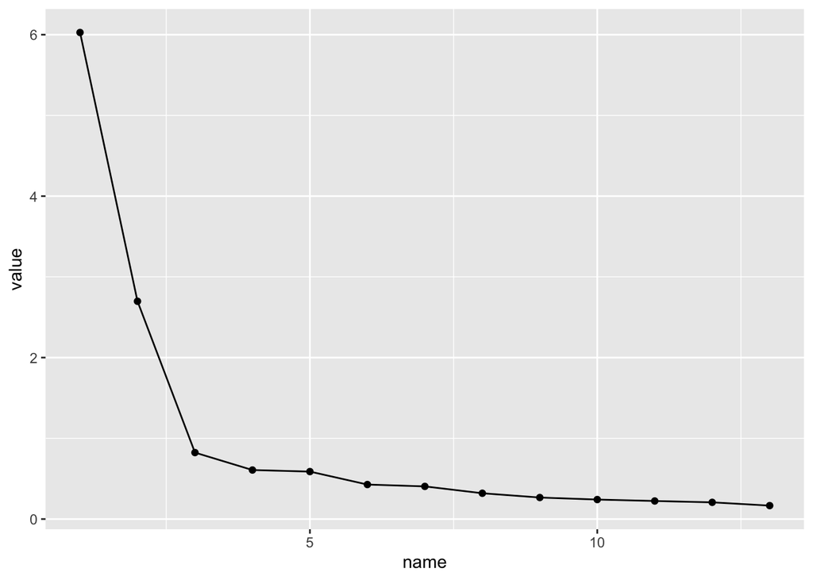

```r
sps %>% cor %>% eigen(only.values = T) %>% `$`(values) %>% enframe() %>% ggplot(aes(name,value))+geom_point()+geom_line()
```

In this case, it looks like we want to choose 3! - the x -value where the line “bends.”

A correlation matrix can also help you decide how many factors you want to extract. Here, bigger circles represent bigger correlations (red = negative, blue = positive).

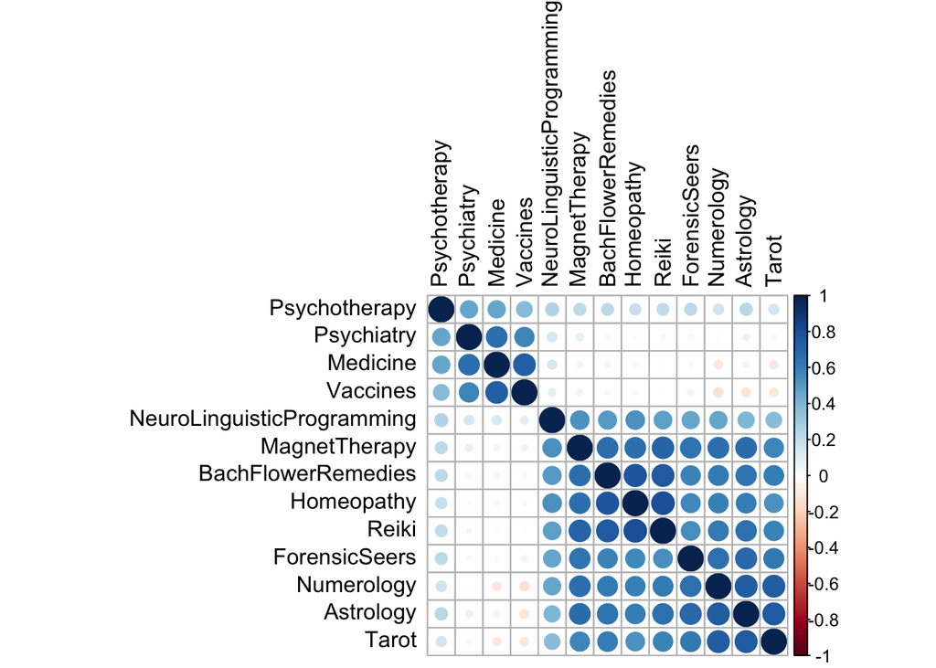

```r
# install.packages("corrplot")

sps %>% #data
  cor() %>% #generate correlations
  corrplot::corrplot(tl.col = "black",order = "hclust") #visualize. Hclust orders correlations.
```

We see that there are two groups of items that are unrelated with each other, but correlated within each group. It seems like science and pseudoscience represent independent factors rather than two ends in a single continuum. Hmmm - that’s intriguing. What are some intuitive explanations for this (intuitive = no stats)? I don’t have the answer, but if I’m doing analysis, I want to stop and think about it!

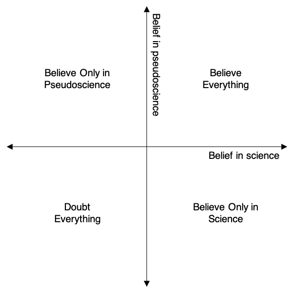

Fig 2. Two independent factors

Based on our theoretical intuitions and all of the evidence we have seen, it makes sense to try and extract two factors. We had two pieces of analysis that said to do 2, and another that said 3. This was ultimately a judgment call as with all stats (5th time I’ve said this - it’s sooooo important!) How would we go about doing that?

## 5.3 How do we extract factors?

We are finally ready to run factor analysis. So far, we figured out that our data is factorizable and that 2 factors are likely the optimum.

**Factor extraction** means generating linear combinations of the variables (13 items) to generate factors (2 in our case). A **linear combination** is just a weighted average of the scores of each participant for each item, to represent the factors. The weights are called factor loadings and represent the correlation between the item and the factor. This is just fancy vocab that scientist like to use to feel smart! It certainly made me feel dumb when I first used it. A linear combination is JUST a weighted average - I am more confident that you understand this terminology!

We still need to make one more decision before extracting our factors. Which factor extraction method will we use? Here are some and their use cases.

| Method | Use case |
| --- | --- |
| Principal Components Analysis (PCA) | Is not “really” factor analysis, but as SPSS default, it is also a default in a lot of published research. |
| Principal Axis Factoring (PAF) | Usually used with normal and continuous data. |
| Maximum Likelihood (ML) | Usually used with normal and continuous data. |
| Unweighted Least Squares (ULS/MinRes) | A more robust variant that works better with non-normal likert type data |
| Unweighted Least Squares (OLS) | A more robust variant that works better with non-normal likert type data |
| Weighted Least Squares (WLS) | A more robust variant that works better with non-normal likert type data |

All of these are available in the `fa()` function from thee psych package, using the `fm =` argument. All of these “work”. Instead of saying that it’s a subjective choice, I’ll just write that I would normally say that it’s a subjective choice.PCA is not available in `fa()` and can be accessed using `principal()`. Our default recommendation for likert items is the ULS factorization method (`fm = "ULS`). This is `fa`’s default.

```r
principal(r = sps,nfactors = 2)
```

```
## Principal Components Analysis
## Call: principal(r = sps, nfactors = 2)
## Standardized loadings (pattern matrix) based upon correlation matrix
##                              RC1   RC2   h2   u2 com
## Psychiatry                  0.04  0.83 0.69 0.31 1.0
## Astrology                   0.85 -0.01 0.73 0.27 1.0
## Medicine                   -0.08  0.90 0.81 0.19 1.0
## Psychotherapy               0.26  0.66 0.51 0.49 1.3
## ForensicSeers               0.79  0.02 0.62 0.38 1.0
## MagnetTherapy               0.84  0.04 0.71 0.29 1.0
## NeuroLinguisticProgramming  0.63  0.22 0.44 0.56 1.2
## Tarot                       0.80 -0.06 0.64 0.36 1.0
## Numerology                  0.84 -0.06 0.71 0.29 1.0
## BachFlowerRemedies          0.84  0.03 0.71 0.29 1.0
## Homeopathy                  0.83  0.03 0.69 0.31 1.0
## Reiki                       0.85  0.05 0.72 0.28 1.0
## Vaccines                   -0.10  0.85 0.73 0.27 1.0
##
##                        RC1  RC2
## SS loadings           6.01 2.71
## Proportion Var        0.46 0.21
## Cumulative Var        0.46 0.67
## Proportion Explained  0.69 0.31
## Cumulative Proportion 0.69 1.00
##
## Mean item complexity =  1
## Test of the hypothesis that 2 components are sufficient.
##
## The root mean square of the residuals (RMSR) is  0.06
##  with the empirical chi square  179.63  with prob <  1.1e-15
##
## Fit based upon off diagonal values = 0.98
```

```r
fit = fa(r = sps,nfactors = 2,fm = "uls")
fit
```

```
## Factor Analysis using method =  uls
## Call: fa(r = sps, nfactors = 2, fm = "uls")
## Standardized loadings (pattern matrix) based upon correlation matrix
##                             ULS1  ULS2   h2   u2 com
## Psychiatry                  0.09  0.74 0.56 0.44 1.0
## Astrology                   0.84 -0.06 0.70 0.30 1.0
## Medicine                   -0.03  0.91 0.83 0.17 1.0
## Psychotherapy               0.28  0.53 0.36 0.64 1.5
## ForensicSeers               0.76 -0.02 0.57 0.43 1.0
## MagnetTherapy               0.82 -0.01 0.68 0.32 1.0
## NeuroLinguisticProgramming  0.59  0.16 0.37 0.63 1.1
## Tarot                       0.77 -0.09 0.60 0.40 1.0
## Numerology                  0.82 -0.10 0.68 0.32 1.0
## BachFlowerRemedies          0.82 -0.02 0.68 0.32 1.0
## Homeopathy                  0.81 -0.01 0.65 0.35 1.0
## Reiki                       0.83  0.01 0.69 0.31 1.0
## Vaccines                   -0.05  0.79 0.63 0.37 1.0
##
##                       ULS1 ULS2
## SS loadings           5.66 2.34
## Proportion Var        0.44 0.18
## Cumulative Var        0.44 0.62
## Proportion Explained  0.71 0.29
## Cumulative Proportion 0.71 1.00
##
## Mean item complexity =  1.1
## Test of the hypothesis that 2 factors are sufficient.
##
## The degrees of freedom for the null model are  78  and the objective function was  8.94 with Chi Square of  2770.09
## The degrees of freedom for the model are 53  and the objective function was  0.93
##
## The root mean square of the residuals (RMSR) is  0.04
## The df corrected root mean square of the residuals is  0.05
##
## The harmonic number of observations is  316 with the empirical chi square  93.13  with prob <  0.00055
## The total number of observations was  316  with Likelihood Chi Square =  286.33  with prob <  9.7e-34
##
## Tucker Lewis Index of factoring reliability =  0.872
## RMSEA index =  0.118  and the 90 % confidence intervals are  0.105 0.132
## BIC =  -18.73
## Fit based upon off diagonal values = 0.99
## Measures of factor score adequacy
##                                                   ULS1 ULS2
## Correlation of (regression) scores with factors   0.97 0.94
## Multiple R square of scores with factors          0.94 0.89
## Minimum correlation of possible factor scores     0.88 0.79
```

Here we run factor analysis and save the results in an object called `fit`. ___________________________________

BONUS SECTION: ROTATIONS. If you’re interested, read about rotations. This is higher level math. If you’re not interested, just skip to the next block of code and run it - then continue on reading.

Before interpreting the results, we should take a look at rotation, the last step, which will improve the interpretability of the results and separate the two factors more clearly.

## 5.4 Rotation (BONUS)

As with factor extraction, there is a large array of rotation methods. The only thing that really matters is whether you are choosing an oblique or an orthogonal rotation. Orthogonal means that you are *forcing* the factors to be perfectly uncorrelated ($r = 0$), whereas in oblique rotation the factors are *allowed* to correlate and the correlation between the factors is calculated.

This should be decided on the basis of theory and empirically–whether your items are actually correlated across factors. Do note, though, that in psychology, factors are almost always correlated. I usually start with an oblique rotation and keep it if the factors are correlated, and I might try an orthogonal rotation if they are unrelated. The rotation is chosen with the `rotate =` parameter within `fa()`.

Some orthogonal rotations: “varimax”, “quartimax”, “bentlerT”, “equamax”, “varimin”, “geominT” and “bifactor” Some oblique rotations: “Promax”, “promax”, “oblimin” (default), “simplimax”, “bentlerQ,”geominQ" and “biquartimin” and “cluster”.

Let us see our rotated factor loading matrix and see how the items are arranged.

BONUS SECTION COMPLETE ___________________________________

WORKSHOP CONTINUED

```r
#MAKE SURE TO SCROLL UP IN THE CONSOLE OUPUT - SOMETIMES THE OUTPUT HERE GETS CUTOFF!
fit = fa(r = sps,nfactors = 2,fm = "uls",rotate = "oblimin")
print.psych(fit,cut=.3,sort=T)
```

```
## Factor Analysis using method =  uls
## Call: fa(r = sps, nfactors = 2, rotate = "oblimin", fm = "uls")
## Standardized loadings (pattern matrix) based upon correlation matrix
##                            item  ULS1  ULS2   h2   u2 com
## Astrology                     2  0.84       0.70 0.30 1.0
## Reiki                        12  0.83       0.69 0.31 1.0
## MagnetTherapy                 6  0.82       0.68 0.32 1.0
## BachFlowerRemedies           10  0.82       0.68 0.32 1.0
## Numerology                    9  0.82       0.68 0.32 1.0
## Homeopathy                   11  0.81       0.65 0.35 1.0
## Tarot                         8  0.77       0.60 0.40 1.0
## ForensicSeers                 5  0.76       0.57 0.43 1.0
## NeuroLinguisticProgramming    7  0.59       0.37 0.63 1.1
## Medicine                      3        0.91 0.83 0.17 1.0
## Vaccines                     13        0.79 0.63 0.37 1.0
## Psychiatry                    1        0.74 0.56 0.44 1.0
## Psychotherapy                 4        0.53 0.36 0.64 1.5
##
##                       ULS1 ULS2
## SS loadings           5.66 2.34
## Proportion Var        0.44 0.18
## Cumulative Var        0.44 0.62
## Proportion Explained  0.71 0.29
## Cumulative Proportion 0.71 1.00
##
## Mean item complexity =  1.1
## Test of the hypothesis that 2 factors are sufficient.
##
## The degrees of freedom for the null model are  78  and the objective function was  8.94 with Chi Square of  2770.09
## The degrees of freedom for the model are 53  and the objective function was  0.93
##
## The root mean square of the residuals (RMSR) is  0.04
## The df corrected root mean square of the residuals is  0.05
##
## The harmonic number of observations is  316 with the empirical chi square  93.13  with prob <  0.00055
## The total number of observations was  316  with Likelihood Chi Square =  286.33  with prob <  9.7e-34
##
## Tucker Lewis Index of factoring reliability =  0.872
## RMSEA index =  0.118  and the 90 % confidence intervals are  0.105 0.132
## BIC =  -18.73
## Fit based upon off diagonal values = 0.99
## Measures of factor score adequacy
##                                                   ULS1 ULS2
## Correlation of (regression) scores with factors   0.97 0.94
## Multiple R square of scores with factors          0.94 0.89
## Minimum correlation of possible factor scores     0.88 0.79
```

The first part of the output gives us what we want the most: our precious *factor loading matrix*. We use the `print.psych` command that allows us to hide small factor loadings (< .3) and sort the factor loading matrix. This simplifies readability and interpretability. We see a nice pattern where all items load highly on their respective factor and have low or null loadings on the different factor. (Try removing the `cut = .3` to see all factor loadings).

We don’t have many problems in this data but here are a few potential problems:

- ```
  Items with very low loadings in all factors: The item doesn't accurately represent any of the factors
  ```

- ```
  Item that loads highly in a factor where it "shouldn't" belong: The item for some reason correlates more with theoretically unrelated (rather than related) items.
  ```

- ```
  Items with high loadings in two factors: The item lacks discriminant validity. It measures two things instead of one.
  ```

- ```
  The sign of the loading is off: A positive sign in the factor loading implies that the item is directly related with the factor. Negative loadings imply that there is an inverse relation. For example: "I feel sad" might load negatively in a measure of happiness.
  ```

The second part of the output gives us *how much of the original variance* of the 13 items is preserved on our two-factor solution. We see that the first factor explains 44% and the second one 18% for a combined 62% of the variance. Take a second to evaluate how good a deal this is. You transformed 13 items into 2 variables (15%), but kept 62% of the information.

We can visualize our results using the plot command. Each axis represents a factor, and points represent items with x and y loadings in each axis. Items on the axis load on a single factor. Items near the origin have loadings that are too low. Items far from the axis, standing in no-man’s land have worse discriminant validity.

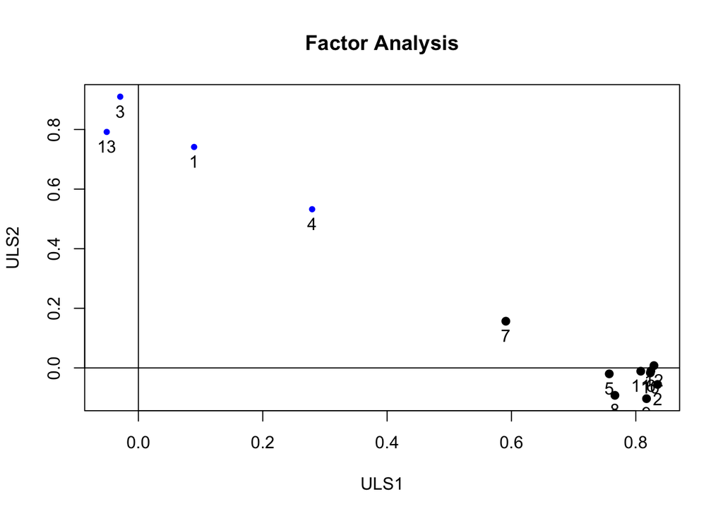

```r
plot(fit)
```

Here, we see that items 4 (psychotherapy) and 7 (neurolinguistic programming) are not as close to their respective axes, indicating small cross loadings. Most other items are right on the axes, meaning they load more univocally on their respective factors.

Finally, let’s use factor scores to see how the 316 people land on these quadrants. BTW, factor scores are the factor analysis cousin of simple composites. They take into account factor loadings to calculate some sort of weighted average of the level of each factor for each person. There are several ways to calculate them, and we won’t go into detail here, but read [this](https://scholarworks.umass.edu/cgi/viewcontent.cgi?article=1226&context=pare) if you are interested.

Since factor scores have means 0, we can use that as a mean split to categorize our participants.

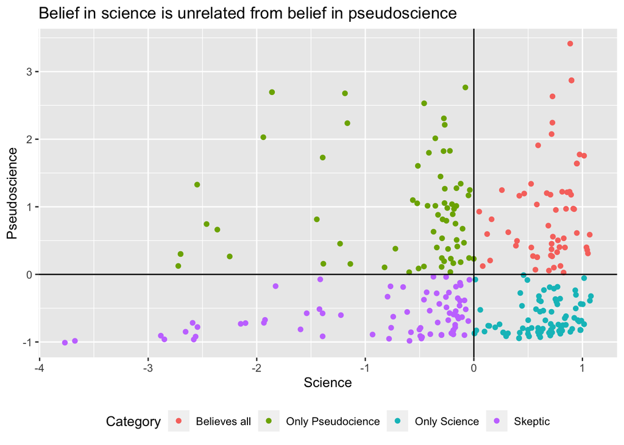

```r
fit$scores %>% as.data.frame() %>%
  rename(Pseudoscience = ULS1,
         Science = ULS2) %>%
  mutate(Category = case_when(Science>0 & Pseudoscience>0 ~ "Believes all",
                              Science<0 & Pseudoscience<0 ~ "Skeptic",
                              Science>0 & Pseudoscience<0 ~ "Only Science",
                              Science<0 & Pseudoscience>0 ~ "Only Pseudocience")) %>%
  ggplot(aes(Science,Pseudoscience,col=Category))+
  geom_point()+
  geom_hline(yintercept = 0)+
  geom_vline(xintercept = 0)+
  labs(title = "Belief in science is unrelated from belief in pseudoscience")+
  theme(legend.position = "bottom")
```

That’s pretty shocking!!!!!! Wouldn’t you think they’d be diametrically opposed? Huh, people are nuanced…

What did we learn? That factor analysis is a *lot* of fun. You have enough information to impress your crush next time you see him/her/them at a party. Just go up to them and be like “Hey, wanna see my factor loadings….” Actually, don’t do that. NEVER do that. This R markdown endorses love, but it does not endorse creepy pick up lines! Just clever pick up lines….

Factor Analysis is a powerful technique that allows you to analyze the interrelations between items. It analyzes the pattern of responses people give to your items to find a way to compress the information in a large number of items into a smaller number of factors while retaining the maximum amount of information. This helps us understand how our measure works and justifies the way we use concrete items to refer to unobservable constructs.

Here is your checklist:

1. Are the items correlated enough? Take a glance at the correlations, see if Bartlett’s Sphericity Test (`cortest.bartlett`) is significant, and Kaiser Meyer Olkin’s Sampmling Adequacy Measure is… well, adequate (`KMO`).
2. Decide how many factors you want to extract. Use a combination of theory, visual inspection of the scree plot (`data %>% cor %>% eigen`), and more advanced methods like parallel analysis (`fa.parallel`) to decide.
3. Choose a factor extraction method (most likely unweighted least squares `fa(data,nfactors,fm='uls)` if you are using likert style items).
4. Choose whether you want orthogonal (e.g. `rotate = "varimax"`), or oblique (e.g. `rotate = "oblimin"`) rotation. Usually factors are related enough to justify oblique rotation, but if upon inspection factors are not correlated, orthogonal rotation might be simpler.
5. Inspect your factor loading matrix to see how good are your items at representing the latent factors.
6. See how much information you could retain.
7. Celebrate because you are finally done!

# 6 Farewell

Way to go! You are now a master of outliers, and helped us solve our failed growth mindset intervention study. You are also an expert psychometrician, and conducted reliability and factor analysis of likert style questionnaires. Okay, you probably don’t really get the factor analysis - but that’s okay. You have to start learning about it somewhere!

See you next week!

# 7 Review: End Notes

## 7.1 Some useful resources to continue your learning

A useful resource, in my opinion, is the [stackoverflow](http://stackoverflow.com/) website. Because this is a general-purpose resource for programming help, it will be useful to use the R tag (`[R]`) in your queries. A related resource is the [statistics stackexchange](http://stats.stackexchange.com/), which is like Stack Overflow but focused more on the underlying statistical issues. **Add other resources**

## 7.2 What’s an R Markdown again?

This is the main kind of document that I use in RStudio, and I think its one of the primary advantage of RStudio over base R console. R Markdown allows you to create a file with a mix of R code and regular text, which is useful if you want to have explanations of your code alongside the code itself. This document, for example, is an R Markdown document. It is also useful because you can export your R Markdown file to an html page or a pdf, which comes in handy when you want to share your code or a report of your analyses to someone who doesn’t have R. If you’re interested in learning more about the functionality of R Markdown, you can visit [this webpage](https://rmarkdown.rstudio.com/lesson-1.html)

You can run lines of code by highlighting them, and pressing COMMAND + ENTER on Mac, or CONTROL + ENTER on PC. If you want to run a whole chunk of code, you can press COMMAND + ALT + C on Mac, or ALT + CONTROL + ALT + C on PC. Alternatively, you can run a chunk of code by clicking the green right-facing arrow at the top-right corner of each chunk. The downward-facing arrow directly left of the green arrow will run all code up to that point.